# Analysis on World Happiness

ETC5513 Assignment 4

Yu Luo, Thakker Khushee, Yunqi Chen

## 0.1 GDP

Table 0.1 shows the average Logged GDP per capita of Regions from high to low. The top 3 regions with the highest GDP are North America and ANZ, Western Europe and East Asia, their GDP is all higher than 10.

The average GDP for all the countries is 9.2957058, and we found three regions’ average GDP are lower than this level: Sub-Saharan Africa, South Asia, Commonwealth of Independent States. We divided into two groups, the regions that regional average GDP higher than global, and regions with regional GDP lower than global, to see how is the relationship between the Logged GDP per capita and the Ladder Score of countries in these regions.

Table 0.1: Average Logged GDP per capita of Regions from High to Low

| Regional indicator | Average |
| --- | --- |
| North America and ANZ | 10.71 |
| Western Europe | 10.69 |
| East Asia | 10.32 |
| Central and Eastern Europe | 9.98 |
| Middle East and North Africa | 9.71 |
| Southeast Asia | 9.37 |
| Latin America and Caribbean | 9.30 |
| Commonwealth of Independent States | 9.21 |
| South Asia | 8.56 |
| Sub-Saharan Africa | 7.90 |

While what we found interesting and different from other Region is in Latin America and Caribbean, some countries even their GDP is lower than the average level, their Ladder Score is high. On the contrary, some countries in the Middle East and North Africa, they got higher GDP score, however, their Ladder Scores are low.

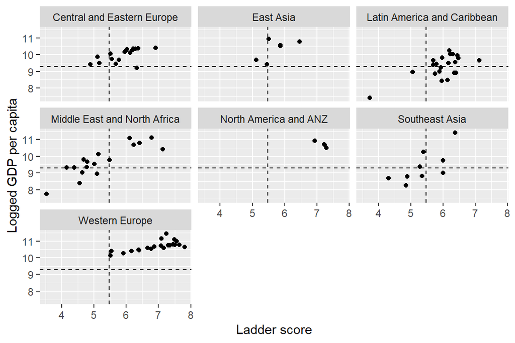

Figure 0.1: Ladder Score vs GDP for the Regions with Regional GDP Means Higher than Total Means

Below Figure 0.2 shows the regions whose regional GDP scores are lower than the average GDP of all the countries, it indicates most countries in these regions, their Ladder Scores are also lower.

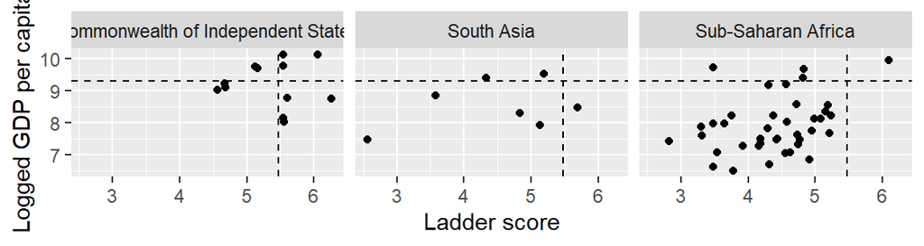

Figure 0.2: Ladder Score vs GDP for the Regions with Regional GDP Means Lower than Total Means

## 0.2 Social Support

The average Social Support of regions from high to low is shown in Table 0.2.

The same method as GDP, we calculated the average Social Support of all counties, it is 0.8087211.

Table 0.2: Average Social Support of Regions from High to Low

| Regional indicator | Average |
| --- | --- |
| North America and ANZ | 0.93 |
| Western Europe | 0.91 |
| Central and Eastern Europe | 0.87 |
| Commonwealth of Independent States | 0.86 |
| East Asia | 0.86 |
| Latin America and Caribbean | 0.86 |
| Southeast Asia | 0.82 |
| Middle East and North Africa | 0.80 |
| South Asia | 0.71 |
| Sub-Saharan Africa | 0.68 |

Either the high Social Support group (shows in Figure 0.3) or low Social Support group (Figure 0.4), we nearly found no country has low Social Support score but got high Ladder Score. The relationship between Social Support and Ladder Score is close to a positive correlation. The better Social Support, the more possible it to get a better Ladder Score; on the opposite, as shown in Figure 0.4, the worse Social Support, the lower the Ladder Score.

But not all the high score Social Support countries also got high Ladder Scores. In Central and Eastern Europe, Commonwealth of Independent States, Middle East and North Africa, South Asia, and Sub-Saharan Africa, some countries with high Social Support scores got low Ladder Scores.

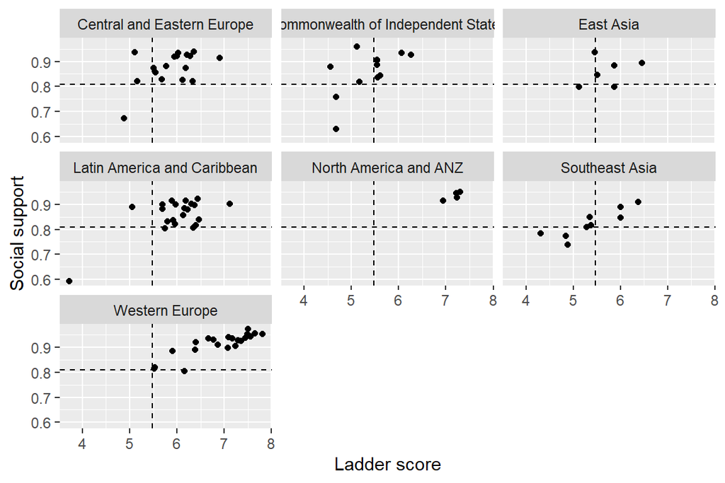

Figure 0.3: Ladder Score vs Social Support for the Regions with Regional Social Support Means Higher than Total Means

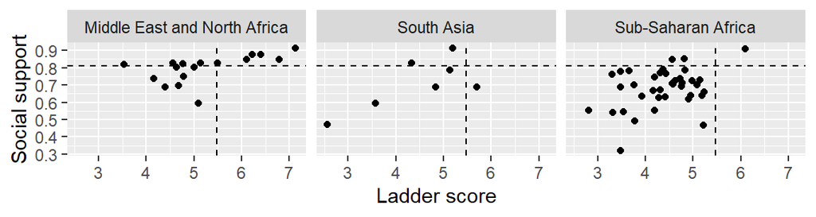

Figure 0.4: Ladder Score vs Social Suppor Lower than Total Means

## 0.3 Healthy Life Expectancy

Table 0.3 shows the ranking of Social Healthy Life Expectancy score of regions.

Table 0.3: Healthy life expectancy

| Regional indicator | Average |
| --- | --- |
| Western Europe | 72.86 |
| North America and ANZ | 72.18 |
| East Asia | 71.09 |
| Central and Eastern Europe | 68.15 |
| Latin America and Caribbean | 66.72 |
| Middle East and North Africa | 65.31 |
| Commonwealth of Independent States | 64.73 |
| Southeast Asia | 64.71 |
| South Asia | 62.45 |
| Sub-Saharan Africa | 55.09 |

In the high Healthy Life Expectancy score countries group, it shows a positive correlation in Southeast Asia, Middle East and North Africa and North America and ANZ. But we found in the Commonwealth of Independent States, Central and Eastern Europe, Western Europe, some countries are almost at the same level of Healthy life Expectancy, their Ladder Scores arrange from a big difference. See that in Figure 0.5.

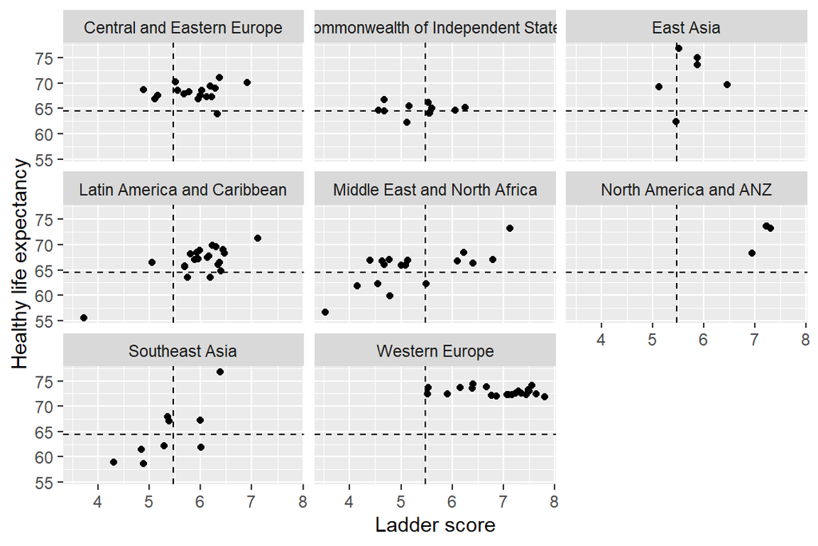

Figure 0.5: Ladder Score vs Healthy Life Expectancy Higher than Total Means

Figure 0.6 shows, in the low Healthy Life Expectancy region, they also have a low Ladder Score, while they don’t look have a special relationship between Healthy Life Expectancy and Ladder Score.

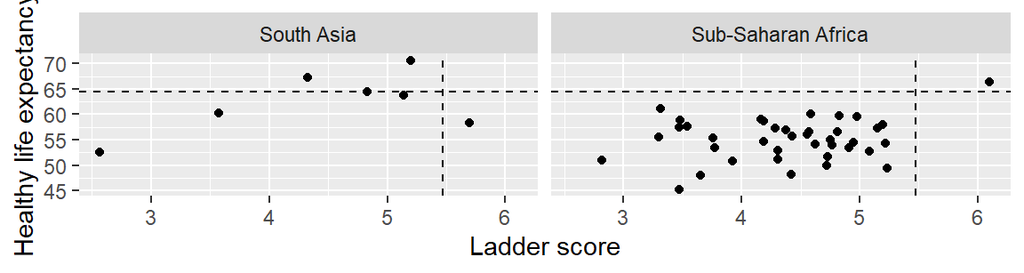

Figure 0.6: Ladder Score vs Healthy Life Expectancy Lower than Total Means

# 1 Conclusion

This analysis illustrated that the world’s happiest countries are primarily in Western Europe, North America, and Australia & New Zealand, the countries in these regions got the higher Ladder Scores.

By analyzing these reports, we are able to decipher what makes countries and their citizens happier, thus allowing us to focus on prioritizing and improving these aspects of each country. It is through this that we are able to achieve the true pursuit of happiness, which we as human beings strive for.

## 1.1 References

World Happiness Report. 2020. The World Happiness Report 2020. [online] Available at: https://worldhappiness.report/ed/2020/

Hadley Wickham and Jennifer Bryan (2019). readxl: Read Excel Files. R package version 1.3.1. https://CRAN.R-project.org/package=readxl

Wickham et al., (2019). Welcome to the tidyverse. Journal of Open Source Software, 4(43), 1686, https://doi.org/10.21105/joss.01686

Sam Firke (2021). janitor: Simple Tools for Examining and Cleaning Dirty Data. R package version 2.1.0. https://CRAN.R-project.org/package=janitor

C. Sievert. Interactive Web-Based Data Visualization with R, plotly, and shiny. Chapman and Hall/CRC Florida, 2020.

Hao Zhu (2021). kableExtra: Construct Complex Table with ‘kable’ and Pipe Syntax. R package version 1.3.4. https://CRAN.R-project.org/package=kableExtra

Yihui Xie (2020). bookdown: Authoring Books and Technical Documents with R Markdown. R package version 0.21.

Yihui Xie (2016). bookdown: Authoring Books and Technical Documents with R Markdown. Chapman and Hall/CRC. ISBN 978-1138700109

H. Wickham. ggplot2: Elegant Graphics for Data Analysis. Springer-Verlag New York, 2016.

Hadley Wickham (2019). stringr: Simple, Consistent Wrappers for Common String Operations. R package version 1.4.0. https://CRAN.R-project.org/package=stringr

Arel-Bundock et al., (2018). countrycode: An R package to convert country names and country codes. Journal of Open Source Software, 3(28), 848, https://doi.org/10.21105/joss.00848